# Viisi syytä sijoittaa ajanilmaus alkuun suomessa (ja miksi niitä on enemmän venäjässä)

## Esityksen kulku

### Ensimmäinen puolikas: yleiskuva

1. Tutkimuksen laajuus + pari sanaa metodista
2. Tilastollinen malli
3. Viisi konstruktiota suomesta

### Toinen puolikas: konkreettinen tapaus

1. Esimerkki venäjän johdantokonstrukiosta
2. Muuttujat, joilla konstruktiota etsitään
3. Tilastollisen mallin tulokset

## Yleiskuva

## Tutkimuksen laajuus

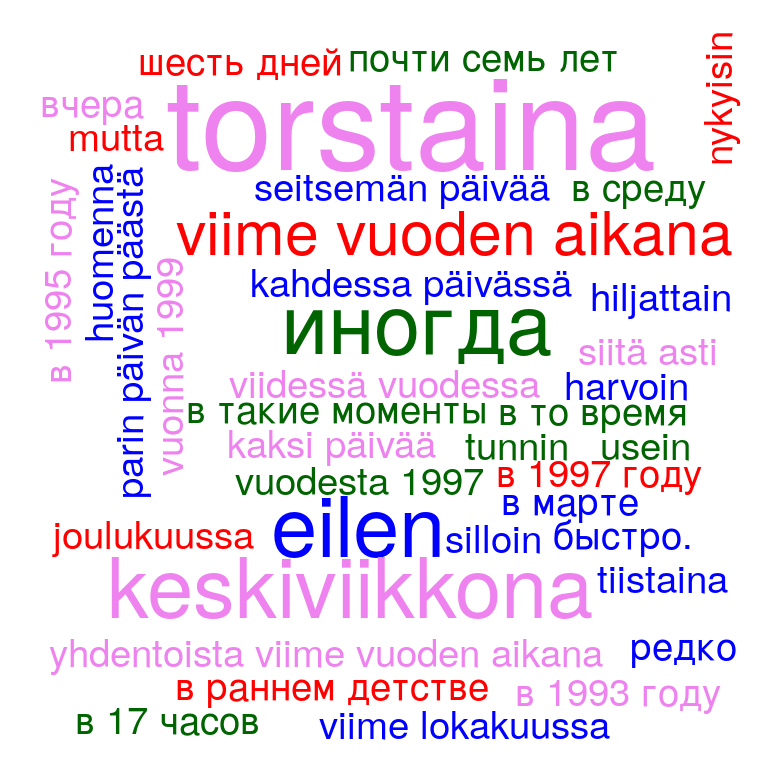

- 50 aineistoryhmää: NP:itä, adverbejä, eri semanttisia luokkia (Haspelmath 1997; Kucera and Trnka 1975)

### Syntaktinen rajaus

- 1S 2V 3O 4 (ei neg)

### Korpukset

- 2 x lehtitekstit (~300 milj.), 2 x internet (~1 mrd)

[figure not shown]

- 73 302
- 86 737
- Konkordanssien automaattinen jäsennys

## Sijaintien jakautuminen suomessa ja venäjässä

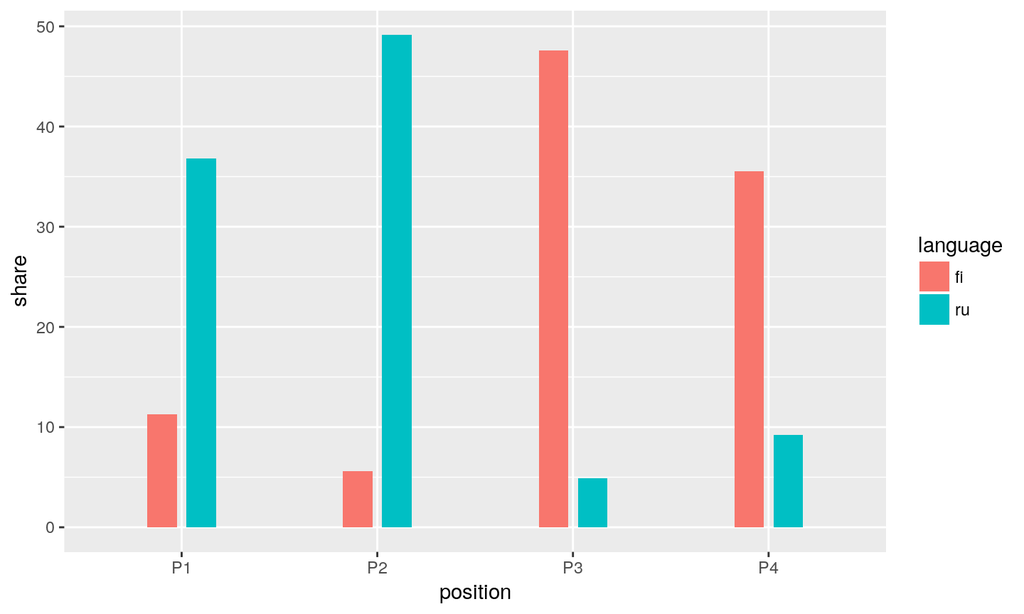

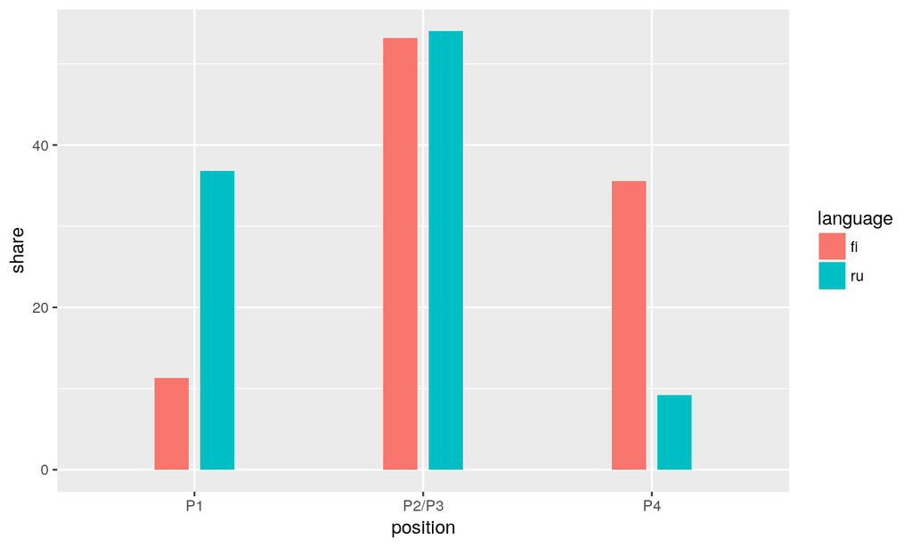

## Regressioanalyysi

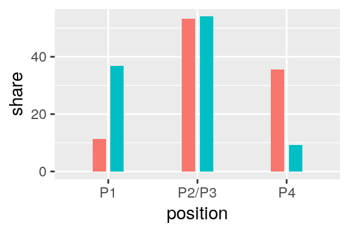

- Lokalisoivat
  - Simultaaninen (*maanantaina*, *puoli kolmelta*, *viime helmikuussa*)
  - Sekventiaalinen (*kahden päivän päästä*, *sodan jälkeen*)
  - Sekventiaalis–duratiivinen (*vuodesta 1987*)
- Ekstensiota ilmaisevat
  - duratiiviset (*kaksi tuntia*, *kauan*)
  - varsinainen resultatiivinen (*kahdessa päivässä*)
  - kehyksinen resultatiivinen (*kahden päivän aikana*)
- Taajuutta ilmaisevat (*joka päivä*, *usein*)
- Likimääräisyyttä ilmaisevat (*viiden maissa*)
- Presuppositionaaliset (*jo*, *vielä*)
- Kieli
- Semanttinen funktio (11)
- Morfologinen rakenne (ADV, NP, Deict.adv)
- Positionaalisuus (Fillmore 1975)
- Numeraalin läsnäolo lauseessa

### Kasvattavat P(S1) suomessa

- Likimääräiset, kehyksiset resultatiiviset, sekventiaaliset
- Numeraalin läsnäolo
- Mm. varsinaiset resultatiiviset **kasvattavat molemmissa kielissä**

### Pienentävät P(S1) suomessa

- Taajuutta ilmaisevat, duratiiviset, sekv.duratiiviset
- Deiktiset adverbit
- Positionaaliset

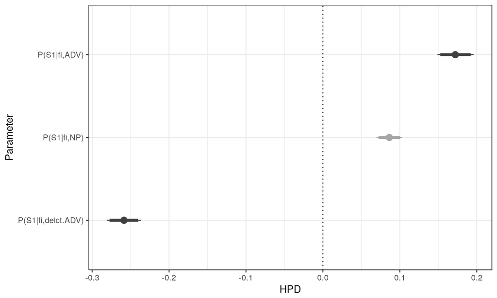

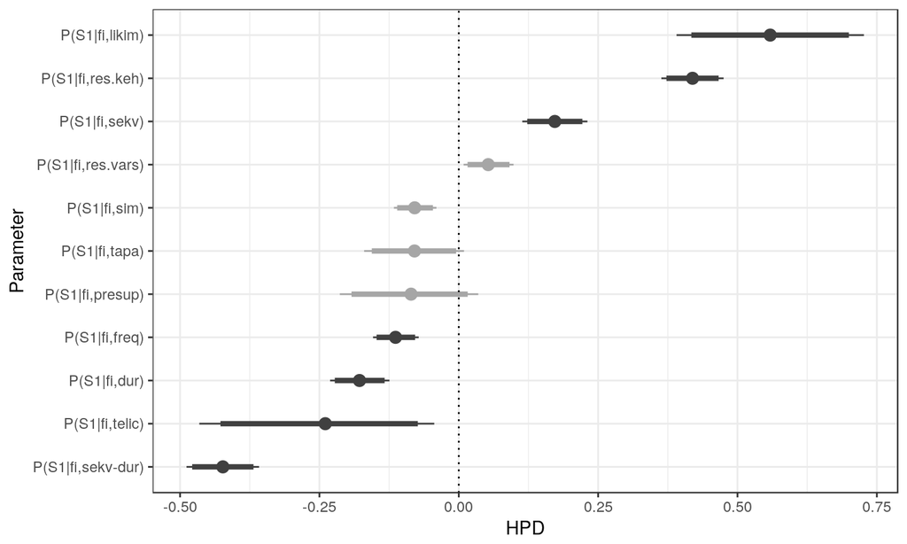

## Viisi syytä

1. *Kolmen maissa iltapäivällä* Pirttimaa hakee vaimonsa takaisin kotiin.[(context)](http://www.studio55.fi/terveys/article/veijon-raskas-osa-dementia-muutti-vaimoni-taysin-vain-42-vuotiaana/126002)
2. *Viime vuoden aikana* työvoimaneuvojat kirjoittivat 11 500 työvoimapoliittista lausuntoa.
3. Minä vain olin ja *puoli kymmeneltä* professori Barnes työnsi käteeni paperilapun ja käski minun kirjoittaa nimeni siihen.
4. *Joka päivä* hän pelasti pieniä lapsia varmalta kuolemalta.
5. *Yleensä* päävoiton voittajat ilmoittautuvat meille heti, mutta *joskus* he odottavat protestiajan päättymistä ennen kuin ottavat yhteyttä.

## Esimerkki venäjälle tyypillisestä konstruktiosta

В среду

keskiviikkona

Госдума

Duuma

на очередном пленарном заседании

täysistunnossa

рассмотрит

käsittelee

ситуацию в Ливии.

Libyan tilanne

Вчера

Eilen

известная ведущая Анфиса Чехова

Tunnettu juontaja Anfisa Tsehova

отпраздновала

vietti

свой день рождения

syntymäpäiväänsä.

- https://newdaynews.ru/moskow/325004.html
- http://topdaynews.ru/index.php?nma=news&fla=stat&nums=8031, 18.8.2017

## Muuttuja 1: subjektin pituus

В среду

Keskiviikkona

специалисты

asiantuntijat

Межгосударственного авиакомитета (МАК)

Kansainvälinen ilmailukomitea-GEN (MAK)

обнародовали

julkistivat

итоги расследования авиакатастрофы

Lento-onnettomuuden tutkimustulokset

В 1997 году

Vuonna 1997

музыкант

muusikko

перенес

kävi läpi

операцию на горле

nieluleikkaus

https://iz.ru/news/319238

## Muuttuja 2: esitelyverbit

Helsingin Sanomat julkisti *eilen* kahden suurimman rakennuttajayhtiön, YH-Rakennuttajien ja Sato-yhtiöiden hallitusten kuntapaikat.

Вчера

Eilen

Ervaz Group

Ervaz Group

представила

esitteli

свои результаты по МСФО

MSFO:ta koskevat tuloksensa

за первое полугодие 2009 года

vuoden 2009 ensimmäiseltä puolikkaalta

- **Muuttuja 3: lehdistö vai internet?**

| verbi | frekvenssi |
| --- | --- |
| опубликовать | 177 |
| подписать | 102 |
| представить | 59 |
| объявить | 47 |
| подтвердить | 47 |
| озвучить | 31 |
| раскрыть | 20 |
| запустить | 15 |
| выпустить | 14 |
| сообщить | 14 |
| презентовать | 13 |
| анонсировать | 12 |
| заявить | 12 |
| Yht. | 563 |

| verbi | frekvenssi |
| --- | --- |
| julkistaa | 109 |
| julkaista | 62 |
| esitellä | 57 |
| allekirjoittaa | 31 |
| esittää | 30 |
| vahvistaa | 30 |
| myöntää | 22 |
| paljastaa | 8 |
| julistaa | 6 |
| lanseerata | 6 |
| Yht. | 361 |

## Spesifimpi regressiomalli (vain eilen-sanat)

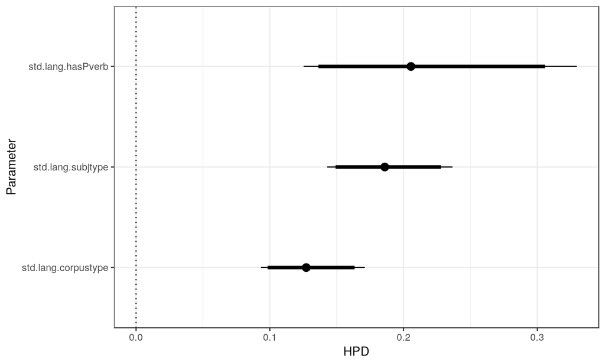

## Subjektin tyyppi

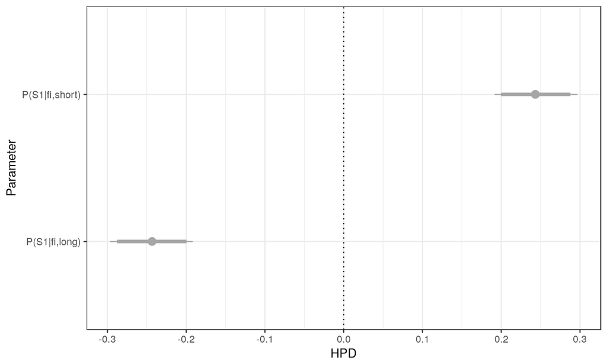

## Korpuksen tyyppi

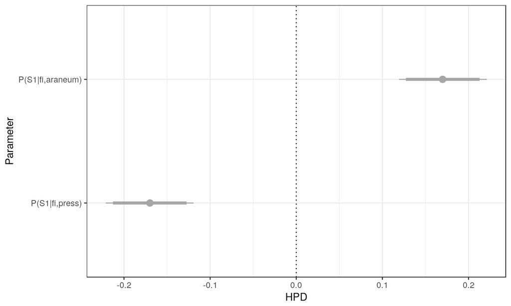

## Esittelyverbin läsnäolo

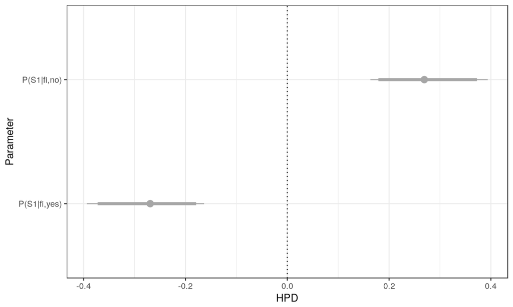

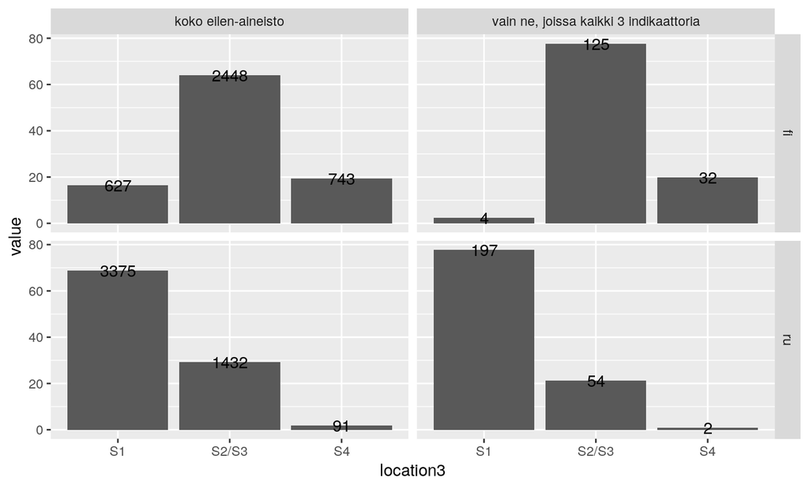

## Kiitos

juho.harme@uta.fi @jharme

Benko, Vladimír. 2014. “Aranea: Yet Another Family of (Comparable) Web Corpora.” In *Text, Speech and Dialogue: 17th International Conference, Tsd 2014, Brno, Czech Republic, September 8-12, 2014. Proceedings*, edited by Petr Sojka, Aleš Horák, Ivan Kopeček, and Karel Pala, 247–56. Cham: Springer International Publishing. doi:10.1007/978-3-319-10816-2_31.

Fillmore, Charles. 1975. “Santa Cruz Lectures on Deixis 1971.” Michigan: Indiana University Linguistics Club. http://www-personal.umich.edu/~jlawler/4-Deixis-I.pdf.

Haspelmath, Martin. 1997. *From Space to Time: Temporal Adverbials in the World’s Languages*. München: Lincom Europa.

Janko, Tatjana. 2001. *Kommunikativnyje Strategii Russkoi Retši*. Moskva: Jazyki slavjanskoj kul’tury.

Kucera, Henry, and Karla Trnka. 1975. *Time in Language*. Michigan: University of Michigan.

Lambrecht, Knud. 1996. *Information Structure and Sentence Form: Topic, Focus, and the Mental Representations of Discourse Referents*. Cambridge: Cambridge university press.

Vilkuna, Maria. 1989. *Free Word Order in Finnish: Its Syntax and Discourse Functions*. Hki: Suomalaisen Kirjallisuuden Seura.